# 1 Basic ODE

Stefan Scholz

2022-09-13

### Background

A unknown disease has been spreading on board of a cruise ship with **2,500 passengers** for **21 days**. Epidemiologists carry out an investigation of the outbreak and are able to determine some of the characteristics of the new pathogen. They find out that initially, **10 infected persons** had boarded the ship and all other passengers never had contact to the pathogen before. Also, once a person gets infected, he or she can immediately transmit the disease to other persons and will stay infectious for **3 days**. After that period a person is suspected to have natural immunity lasting around **180 days**.

On average, each person had around **5 contacts** to other passengers and from the initial analysis, the index case infected on average **40 percent** of their contacts (secondary attack rate).

You are asked to do some modeling exercises to fill knowledge gaps and help decision makers to find appropriate measures to contain this outbreak or following outbreaks.

You are given some basic computer code, describing a simple *Susceptible-Infected-Recovered* model.

```r
library(tidyverse)
library(deSolve)

sir <- function(time, state, parms) {
  # calculate number of populaton size from compartments
  N <- state[1] + state[2] + state[3]
  # calculate the number of new infections
  flow.I <- (state[1] * parms[["beta"]]) * (parms[["contacts"]] %*% (state[2]/N))
  # Increment the number of persons in each compartment
  dS <- -flow.I
  dI <-  flow.I - parms[["gamma"]] * state[2]
  dR <-         + parms[["gamma"]] * state[2]
  # return result
  return(list(c(dS, dI, dR, flow.I)))
}

##### Transform lsoda-output to data-frame in long-format
run.ode <- function(times, inits, parms, ode.func) {
  out.ode <- lsoda(y = inits, times = times, func = ode.func, parms = parms) %>%
    as.data.frame() %>% pivot_longer(names_to = "STATE", values_to = "VALUE", !1)
  return(out.ode)
}

plot.ode <- function(df) {
  df <- df %>% filter(STATE != "flow.I")
  p <- ggplot()
  p <- p + geom_line(data = df, aes(x=time, y = VALUE, color=STATE))
  p <- p + theme_bw() + theme(legend.position = "bottom")
  p
}
```

### Mandatory exercises

1. Look at the documentation of the *lsoda* function from the *deSolve* library. Which variable types are needed for the function arguments for *y*, *times*, *func* and *parms*? Add the necessary arguments to incorporate the information from the outbreak investigation into your model. Try to call the *run.ode* function and plot the output using the *plot.ode* function.

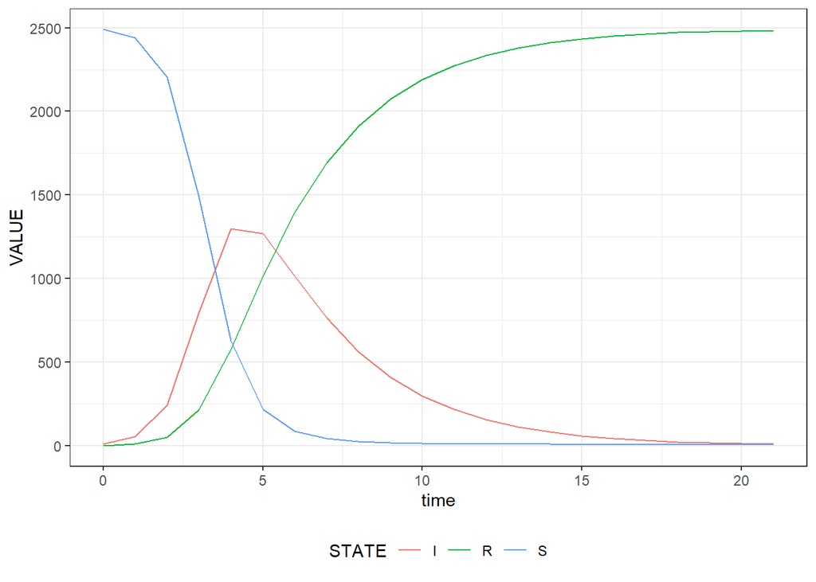

```r
inits <- c(S = 2490, I = 10, R = 0, flow.I = 0)
times <- 0:21
parms <- list(gamma = 1/3,
              beta = 0.4,
              contacts = 5)
res.sir <- run.ode(times = times, inits = inits, parms = parms, ode.func = sir)
plot.ode(res.sir)
```

2. Extend the system of differential equations to allow the model to allow for re-infections and change the function inputs accordingly.

```r
sirs <- function(time, state, parms) {
  # calculate number of populaton size from compartments
  N <- state[1] + state[2] + state[3]
  # calculate the number of new infections
  flow.I <- (state[1] * parms[["beta"]]) * (parms[["contacts"]] %*% (state[2]/N))
  # Increment the number of persons in each compartment
  dS <- -flow.I                               + parms[["sigma"]] * state[3]
  dI <-  flow.I - parms[["gamma"]] * state[2]
  dR <-         + parms[["gamma"]] * state[2] - parms[["sigma"]] * state[3]
  # return result
  return(list(c(dS, dI, dR, flow.I)))
}

parms <- list(gamma = 1/3,
              sigma = 1/180,
              beta = 0.4,
              contacts = 5)
```

3. Get to know your model. How do the results change with changes of the parameter values?

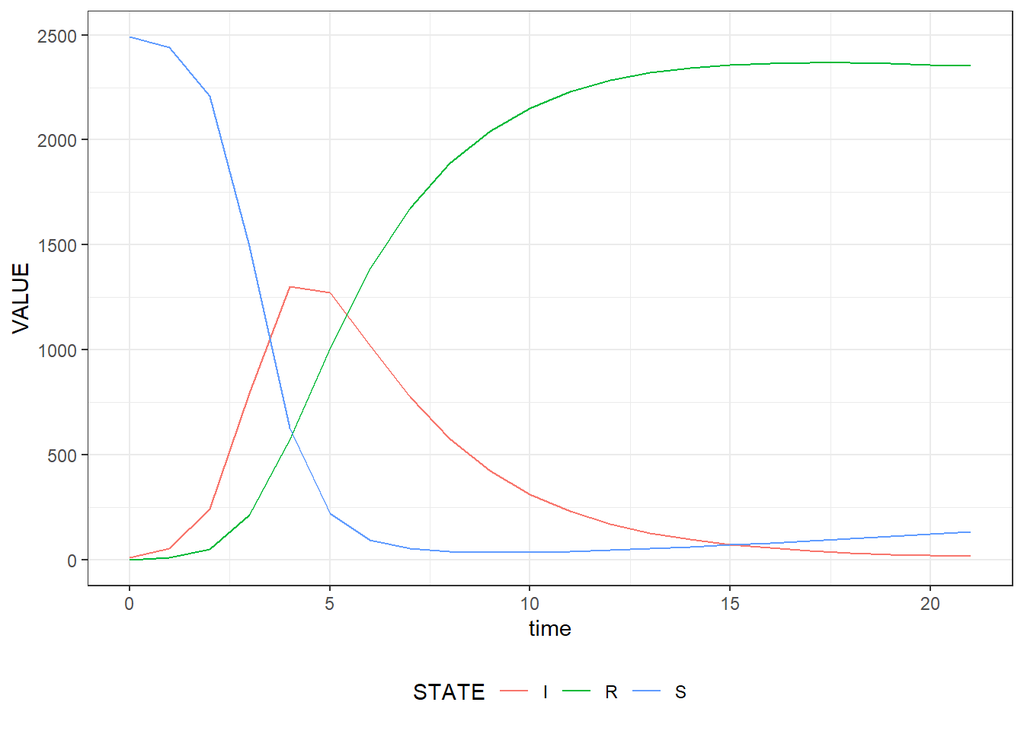

```r
res.ode <- run.ode(times = times, inits = inits, parms = parms, ode.func = sirs)
plot.ode(res.ode)
```

4. What happens when you change the time horizon of the model? How do you explain what happens over 500 days?

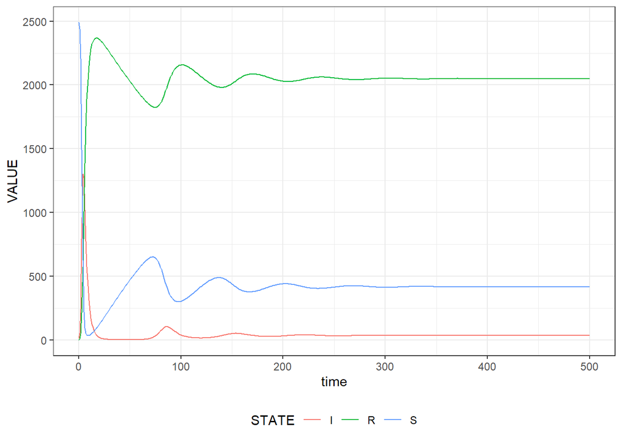

```r
times <- 0:500
res.ode <- run.ode(times = times, inits = inits, parms = parms, ode.func = sirs)
plot.ode(res.ode)
```

### Advanced exercises

(Please save these exercises in separate files, as the following exercises will continue only after the mandatory part)

#### Splitting flows

Assume that **50 percent** of newly infected persons end up being asymptomatic and non-infectious, but are still acquiring natural immunity.

- Add a new compartment for asymptomatic infected persons and incorporate a parameter governing the proportion of asymptomatics.
- How does the model need to be adopted to allow for a reduced infectiousness of 50% for asymptomatic persons?

```r
sirs <- function(time, state, parms) {
  # calculate number of populaton size from compartments
  N <- state[1] + state[2] + state[3] + state[4]
  # calculate the number of new infections
  flow.I <- (state[1] * parms[["beta"]]) * (parms[["contacts"]] %*% ((state[2] + state[3] * params[["theta"]])/N))
  # Increment the number of persons in each compartment
  dS <- -flow.I                                                     + parms[["sigma"]] * state[4]
  dA <-  flow.I * parms[["epsilon"]]  - parms[["gamma"]] * state[2]
  dI <-  flow.I * parms[["epsilon"]]  - parms[["gamma"]] * state[3]
  dR <-                               + parms[["gamma"]] * (state[2] + state[3]) - parms[["sigma"]] * state[4]
  # return result
  return(list(c(dS, dA, dI, dR, flow.I)))
}

inits <- c(S = 2490, A = 5, I = 5, R = 0, flow.I = 0)
times <- 0:21
parms <- list(gamma = 1/3,
              sigma = 1/180,
              epsilon = 0.5,
              theta = 0.5,
              beta = 0.4,
              contacts = 5)
```

#### Demographics

Each day the cruise ship enters a port and about 10% of the passengers leave and are replaced by new (healthy) travelers.

- Think about different ways how to implement this into the model (How could you implement weekly boarding?). What are pros and cons of the different ways?
- Actually try to implement one of the approaches. How does this shape the transmission of the disease? And what happens if you vary the amount of passengers unboarding/boarding each day?

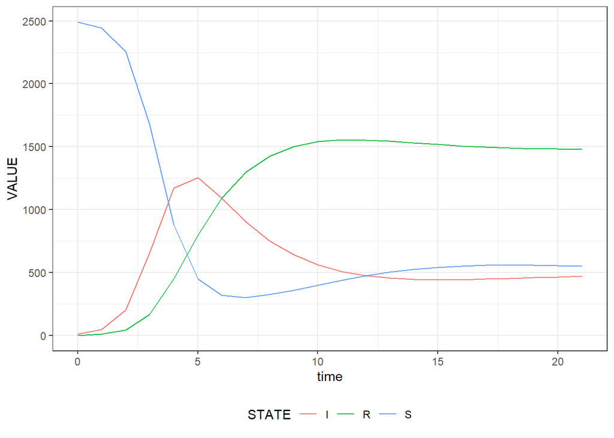

```r
# Solution 1 -- continous demographics
sirs <- function(time, state, parms) {
  # calculate number of populaton size from compartments
  N <- state[1] + state[2] + state[3]
  # calculate the number of new infections
  flow.I <- (state[1] * parms[["beta"]]) * (parms[["contacts"]] %*% (state[2]/N))
  # Increment the number of persons in each compartment
  dS <- -flow.I                               + parms[["sigma"]] * state[3] - state[1] * parms[["delta"]]  + N * parms[["omicron"]]
  dI <-  flow.I - parms[["gamma"]] * state[2]                               - state[2] * parms[["delta"]]
  dR <-         + parms[["gamma"]] * state[2] - parms[["sigma"]] * state[3] - state[3] * parms[["delta"]]
  # return result
  return(list(c(dS, dI, dR, flow.I)))
}
inits <- c(S = 2490, I = 10, R = 0, flow.I = 0)
times <- 0:21
parms <- list(gamma = 1/3,
              sigma = 1/180,
              delta = 0.1,
              omicron = 0.1,
              beta = 0.4,
              contacts = 5)
res.ode <- run.ode(times = times, inits = inits, parms = parms, ode.func = sirs)
plot.ode(res.ode)
```

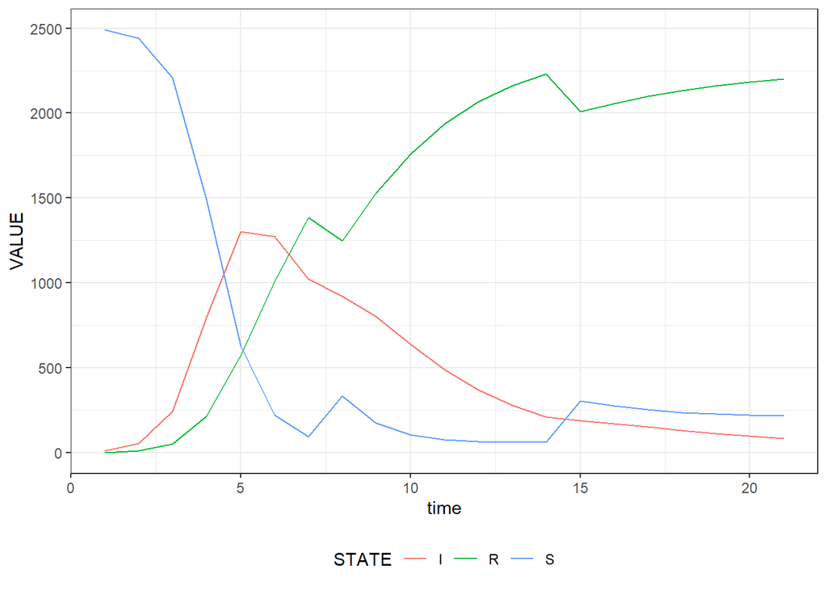

```r
# Solution 2 -- discrete demographics
sirs <- function(time, state, parms) {
  # calculate number of populaton size from compartments
  N <- state[1] + state[2] + state[3]
  # calculate the number of new infections
  flow.I <- (state[1] * parms[["beta"]]) * (parms[["contacts"]] %*% (state[2]/N))
  # Increment the number of persons in each compartment
  dS <- -flow.I                               + parms[["sigma"]] * state[3]
  dI <-  flow.I - parms[["gamma"]] * state[2]
  dR <-         + parms[["gamma"]] * state[2] - parms[["sigma"]] * state[3]
  # return result
  return(list(c(dS, dI, dR, flow.I)))
}

inits <- c(S = 2490, I = 10, R = 0, flow.I = 0)
times <- 1:7
parms <- list(gamma = 1/3,
              sigma = 1/180,
              beta = 0.4,
              delta = 0.1,
              omicron = 0.1,
              contacts = 5)

results <- list()
for (i in 1:3){

  res.ode <- run.ode(times = times, inits = inits, parms = parms, ode.func = sirs) %>% mutate(time = time + (i - 1) * 7)
  results[[i]] <- res.ode

  inits <- res.ode %>% filter(time == max(time)) %>% dplyr::select(-time) %>% pivot_wider(names_from = "STATE", values_from = "VALUE")
  inits <- c(S = inits$S * (1 - parms[["delta"]]) + (inits$S + inits$I + inits$R) * parms[["omicron"]],
             I = inits$I * (1 - parms[["delta"]]),
             R = inits$R * (1 - parms[["delta"]]),
             flow.I = 0)
}

res.ode <- bind_rows(results)

plot.ode(res.ode)
```

#### Time dependencies

Acute Respiratory Infections (ARI) tend to follow strong seasonal patterns with a higher number of cases in autumn/winter compared to spring/summer.

- Which parameter would you change to include seasonality?

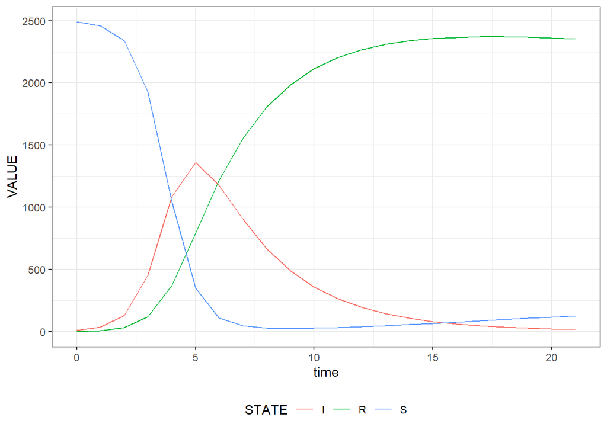

```r
sirs <- function(time, state, parms) {
  # calculate number of populaton size from compartments
  N <- state[1] + state[2] + state[3]
  # calculate the number of new infections
  flow.I <- (state[1] * parms[["beta"]] *(1 + parms[["tau"]] * cos(2*pi*(time-7)/14))) * (parms[["contacts"]] %*% (state[2]/N))
  # Increment the number of persons in each compartment
  dS <- -flow.I                               + parms[["sigma"]] * state[3]
  dI <-  flow.I - parms[["gamma"]] * state[2]
  dR <-         + parms[["gamma"]] * state[2] - parms[["sigma"]] * state[3]
  # return result
  return(list(c(dS, dI, dR, flow.I)))
}

inits <- c(S = 2490, I = 10, R = 0, flow.I = 0)
times <- 0:21
parms <- list(gamma = 1/3,
              sigma = 1/180,
              tau = 0.2, # max amplitude of seasonality
              beta = 0.4,
              contacts = 5)

res.ode <- run.ode(times = times, inits = inits, parms = parms, ode.func = sirs)
plot.ode(res.ode)
```

- How could you incorporate ‘’breaking points’’ or special periods (e.g., Oktoberfest) in the transmission process, i.e., time-dependent step- or indicator-functions?

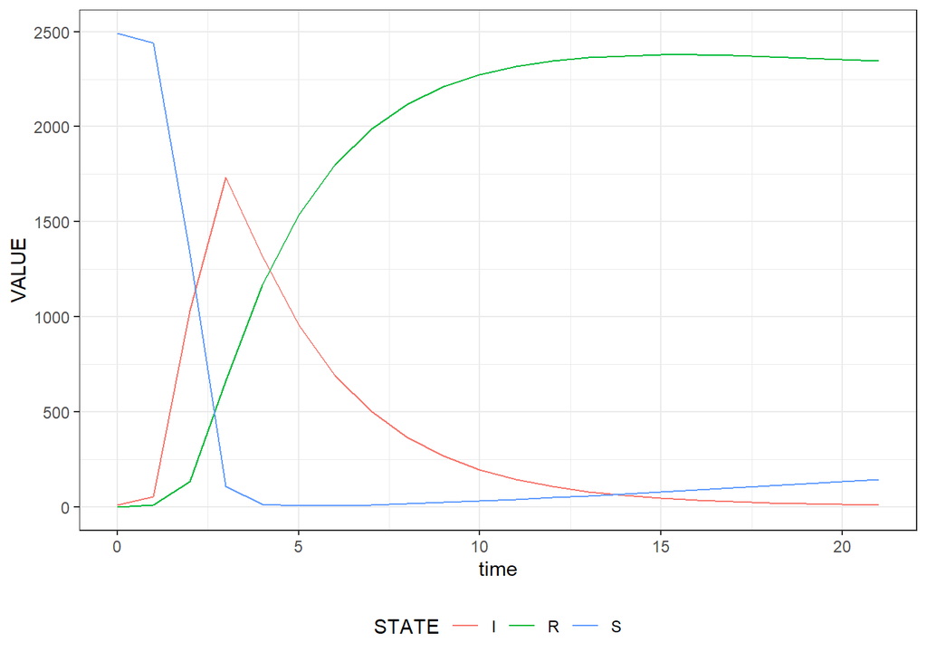

```r
sirs <- function(time, state, parms) {
  # calculate number of populaton size from compartments
  N <- state[1] + state[2] + state[3]
  # calculate the number of new infections
  flow.I <- (state[1] * ifelse(time > parms[["wiesn"]][1] & time < parms[["wiesn"]][2], parms[["beta.wiesn"]], parms[["beta"]]) * (parms[["contacts"]] %*% (state[2]/N)))
  # Increment the number of persons in each compartment
  dS <- -flow.I                               + parms[["sigma"]] * state[3]
  dI <-  flow.I - parms[["gamma"]] * state[2]
  dR <-         + parms[["gamma"]] * state[2] - parms[["sigma"]] * state[3]
  # return result
  return(list(c(dS, dI, dR, flow.I)))
}

inits <- c(S = 2490, I = 10, R = 0, flow.I = 0)
times <- 0:21
parms <- list(gamma = 1/3,
              sigma = 1/180,
              wiesn = c(1, 7),
              beta = 0.4,
              beta.wiesn = 0.8,
              contacts = 5)

res.ode <- run.ode(times = times, inits = inits, parms = parms, ode.func = sirs)
plot.ode(res.ode)
```

#### Dynamic vs. static components

- Incorporate a “death” compartment into your model. How can you incorporate death directly at infection and how during the infectious period (see *splitting flows* exercise)

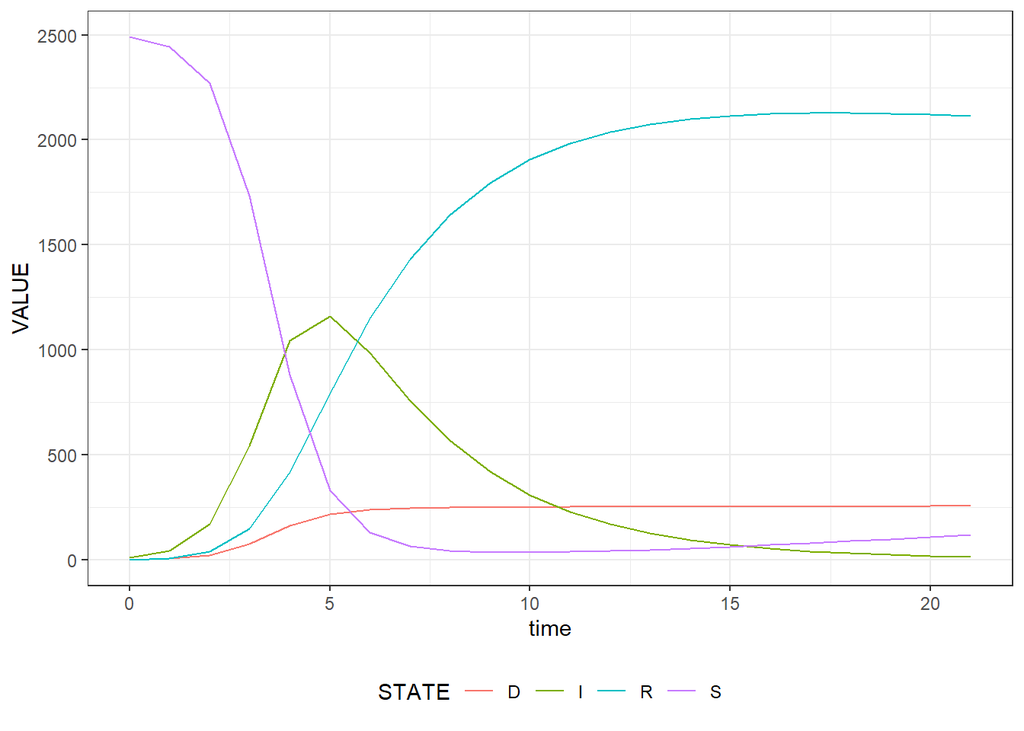

```r
# solution 1 -- death at infection
sirs <- function(time, state, parms) {
  # calculate number of populaton size from compartments
  N <- state[1] + state[2] + state[3]
  # calculate the number of new infections
  flow.I <- (state[1] * parms[["beta"]]) * (parms[["contacts"]] %*% (state[2]/N))
  # Increment the number of persons in each compartment
  dS <- -flow.I                                                     + parms[["sigma"]] * state[3]
  dI <-  flow.I * (1 - parms[["xi"]]) - parms[["gamma"]] * state[2]
  dR <-                               + parms[["gamma"]] * state[2] - parms[["sigma"]] * state[3]
  dD <- + flow.I * parms[["xi"]]
  # return result
  return(list(c(dS, dI, dR, dD, flow.I)))
}
inits <- c(S = 2490, I = 10, R = 0, D = 0, flow.I = 0)
parms <- list(gamma = 1/3,
              sigma = 1/180,
              beta = 0.4,
              xi = 0.1,
              contacts = 5)

res.ode <- run.ode(times = times, inits = inits, parms = parms, ode.func = sirs)
plot.ode(res.ode)
```

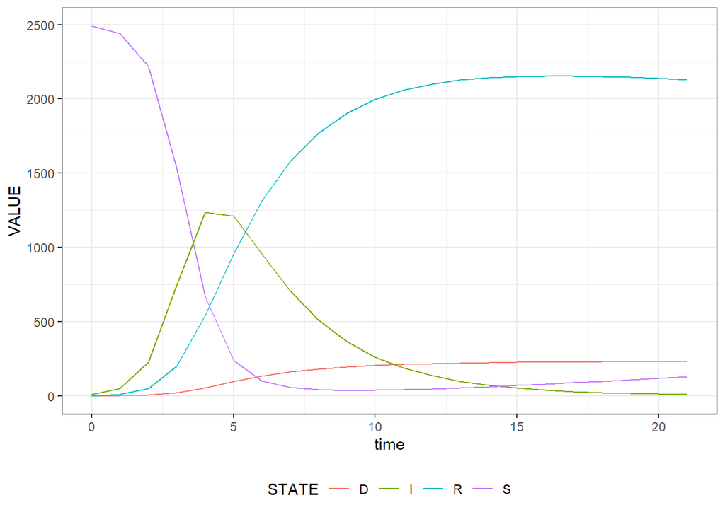

```r
sirs <- function(time, state, parms) {
  # solution 2 -- death during infection period
  # calculate number of populaton size from compartments
  N <- state[1] + state[2] + state[3]
  # calculate the number of new infections
  flow.I <- (state[1] * parms[["beta"]]) * (parms[["contacts"]] %*% (state[2]/N))
  # Increment the number of persons in each compartment
  dS <- -flow.I                               + parms[["sigma"]] * state[3]
  dI <-  flow.I - parms[["gamma"]] * state[2]                               - state[2] * (parms[["xi"]] * parms[["gamma"]])
  dR <-         + parms[["gamma"]] * state[2] - parms[["sigma"]] * state[3]
  dD <-                                                                     + state[2] * (parms[["xi"]] * parms[["gamma"]])
  # return result
  return(list(c(dS, dI, dR, dD, flow.I)))
}
inits <- c(S = 2490, I = 10, R = 0, D = 0, flow.I = 0)
parms <- list(gamma = 1/3,
              sigma = 1/180,
              beta = 0.4,
              xi = 0.1,
              contacts = 5)

res.ode <- run.ode(times = times, inits = inits, parms = parms, ode.func = sirs)
plot.ode(res.ode)
```

- Compare the number of deaths from the ODE model with a death compartment to the deaths calculated applying the lethality to the incident cases from the previous SIR model. What happens when you increase the lethality rate?

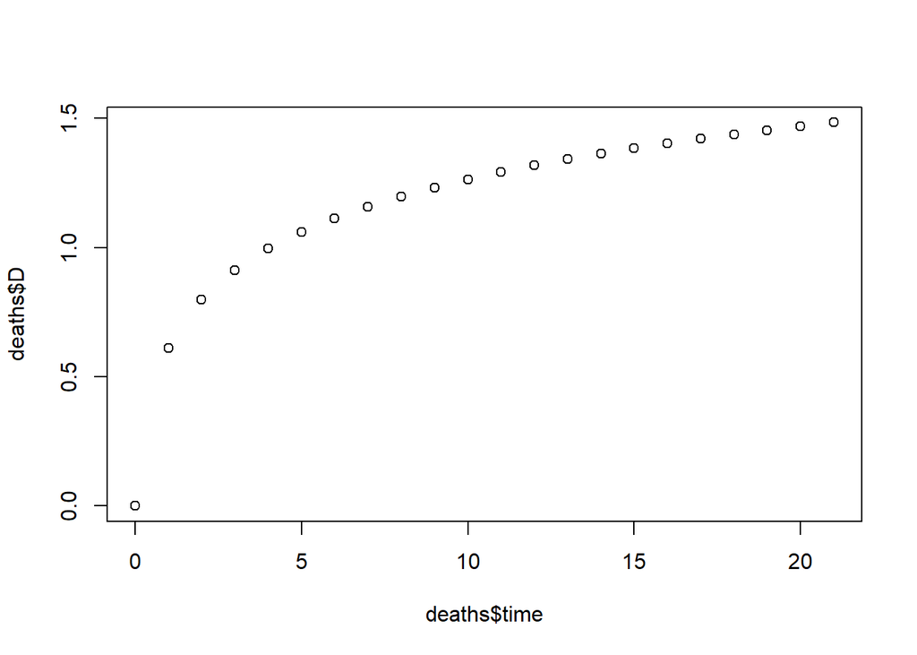

```r
sirs <- function(time, state, parms) {
  # calculate number of populaton size from compartments
  N <- state[1] + state[2] + state[3]
  # calculate the number of new infections
  flow.I <- (state[1] * parms[["beta"]]) * (parms[["contacts"]] %*% (state[2]/N))
  # Increment the number of persons in each compartment
  dS <- -flow.I                                 + parms[["sigma"]] * state[3]
  dI <-  flow.I * - parms[["gamma"]] * state[2]
  dR <-           + parms[["gamma"]] * state[2] - parms[["sigma"]] * state[3]
  # return result
  return(list(c(dS, dI, dR, flow.I)))
}
inits <- c(S = 2490, I = 10, R = 0, flow.I = 0)
parms <- list(gamma = 1/3,
              sigma = 1/180,
              beta = 0.4,
              xi = 0.1,
              contacts = 5)

res.ode <- run.ode(times = times, inits = inits, parms = parms, ode.func = sirs)

deaths <- res.ode %>% filter(STATE == "flow.I") %>% mutate(D = VALUE * parms[["xi"]])

plot(deaths$time, deaths$D)
```